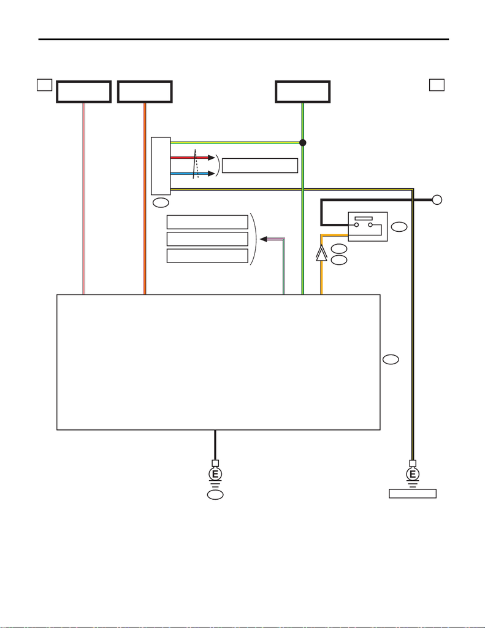

WI-412

Vehicle Dynamics Control System

WIRING SYSTEM

58.Vehicle Dynamics Control System

A: WIRING DIAGRAM

21

WI-44602

a a

A

R/Y

G/Y

W/RW/R26

R/Y1

G/Y31

B

MB-1

SBF-1

(B)

B310

VDC CM

i234

B552

i230

O

B6

O5

30

P/G

8

GV

38B

B231

R

L

G/Y

3

2

B/Y1

4

B/Y

REF. TO CAN COMMUNICATION

SYSTEM [a]

FB-44

F/B FUSE NO. 33

(IG)

MB-2

M/B FUSE NO. 1

(B)

REF. TO PUSH BUTTON START

SYSTEM [1c] [2c]

REF. TO NAVIGATION

SYSTEM [1a] [2a]

REF. TO AUDIO

SYSTEM [1c] [2a] [3c] [4a]

VDC OFF SWITCH

REF. TO GND [c]

STEERING

ANGLE

SENSOR

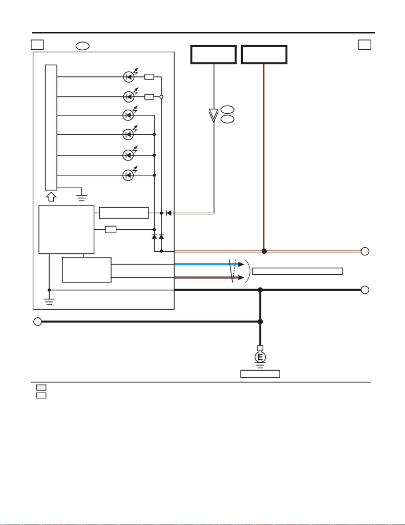

WI-413

Vehicle Dynamics Control System

WIRING SYSTEM

WI-44603

b b

B551

i229

i10

B

I/F

C

A

W/L40

38 B

L

R

32

33

BR/W

B

B B

BR/W

20

VDC OFF

ABS

BR/W

W/L

W/L W/L

3

B

EJ

FA

HILL START ASSIST

FB-18

F/B FUSE NO. 7

(B)

CAN TRANSCEIVER &

RECEIVER

MICRO COMPUTER

VDC WARNING/VDC OPERATION

PARKING BRAKE/

BRAKE FLUID LEVEL

DRIVE CIRCUIT

REF. TO CAN COMMUNICATION SYSTEM [b]

FB-12

F/B FUSE NO. 2

(IG)

REF. TO GND [e]

POWER SUPPLY

CIRCUIT

COMBINATION METER

PARKING BRAKE/

BRAKE FLUID LEVEL/

BRAKE VACUUM PUMP

FA

EJ

: ENGINE TYPE EJ

: ENGINE TYPE FA

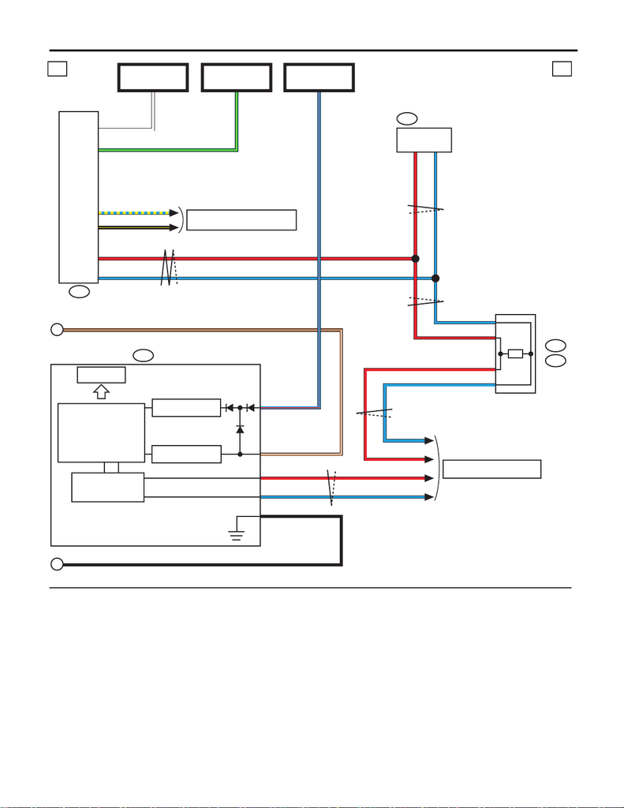

WI-414

Vehicle Dynamics Control System

WIRING SYSTEM

c c

A:

WI-44604

B

C

MFD

DATA LINK

CONNECTOR

i122

B40

BR/W

BR/W

A1

A6

A2

A5

A3

L/R

L

R

R

L

B28

B20

C27

C35

16 W

8 G/Y

6R

14 L

L/R

36R

35L

B

L

R

TFT

B

B310

VDC CM

REF. TO ENGINE ELECTRICAL

SYSTEM [1g] [2g] [3f] [4f]

15

B/Y4

REF. TO CAN COMMUNICATION

SYSTEM [b]

1

C: i84

B: B281

I/F

CAN TRANSCEIVER &

RECEIVER

MICRO COMPUTER

FB-10

M/B FUSE NO. 8

(B)

MB-27

M/B FUSE NO. 13

(B)

FB-32

F/B FUSE NO. 4

(IG)

CONSTANT VOLTAGE

CIRCUIT

IG DETECTING

CIRCUIT

BODY

INTEGRATED

UNIT

: ENGINE TYPE FA : B/R

ENGINE TYPE EJ : B/W

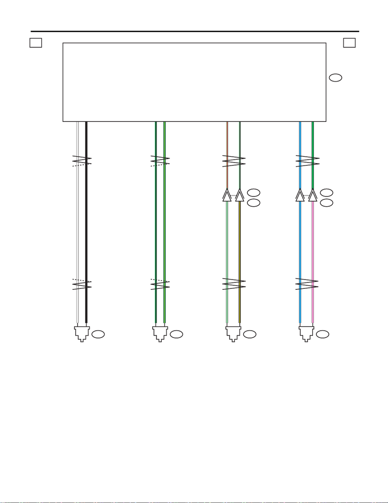

WI-415

Vehicle Dynamics Control System

WIRING SYSTEM

WI-44605

d d

B15 B6 R73 R72

B97

R1

B99

R3

12

13

3

2

6

5

9

10

2

1

B

W

2

1 G/B

G/O

1

2

1

2

LG

B/Y

L

P

B310

W

B

G/B

G/O

LG/R

LG/B

L

G

LG/R

LG/B

L

G

LG

B/Y

L

P

8

9

17

18

VDC CM

REAR ABS

WHEEL SPEED

SENSOR RH

REAR ABS

WHEEL SPEED

SENSOR LH

FRONT ABS

WHEEL SPEED

SENSOR RH

FRONT ABS

WHEEL SPEED

SENSOR LH

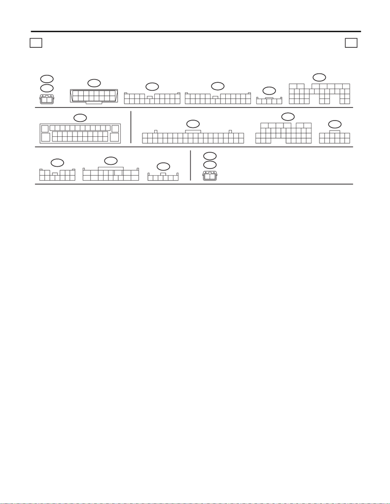

WI-416

Vehicle Dynamics Control System

WIRING SYSTEM

(GR)

R73

12

(GR)

R72

B281B:

29

10 11 12 13 14 15

2524

16

30

98

17 18 19

20

28

21 22 23

3231

26 27

33 34 35

i84C:

19

18

21

20

2322 24 25 26

17

1

23

4

56

27

28 29 30

31 32 33 34 35

798

151413121110 16

WI-44606

e e

(GR)

B15

(GR)

B6

12

89

19 20

10 11 12 13 14 15 16 17 18

B97

3412 89

10 11

12 13 14 15 16 17 18 19 20 21 22 23 24

567

B99

B231

5341

2

B310

23456789

1

10 11 12 13

14

15

26

16 17 18 19 20 21 22 23 24 25

27 28 29 30 31 32 33 34 35 36 37

38

i10

11 12

9

10

7856341

2

15 1613 14 19

18

20

21 22 23 24 26

25

27 28 29 30 31 32 33 34 35 36 37 38 39 40

17

11 12

9

10

78

65341

2

i122

(B)

A:

i234

(GR)

63451

2

B40

(B)

1

9

8

16

2

10

7

15

3

11

6

14

4

12

5

13

i230

(GR)

10

13

345 6

14 15 16 17

1211

12 78

9

i229

12 345

6789

10 11 12

LIST OF CONNECTORS